# Human Activity Recognition Project

PS

19 June 2015

# Executive Summary

This Project aims to predict how well a group of participants performed a Weight-Lifting Exercise, by application of a Machine Learning Algorithm on data captured by sensors while they performed the exercises. This Project is a part of the Predictive Machine Learning class on Coursera.

## Background

Using devices such as Jawbone Up, Nike FuelBand, and Fitbit it is now possible to collect a large amount of data about personal activity relatively inexpensively. These type of devices are part of the quantified self movement – a group of enthusiasts who take measurements about themselves regularly to improve their health, to find patterns in their behavior, or because they are tech geeks. One thing that people regularly do is quantify how much of a particular activity they do, but they rarely quantify how well they do it. In this project, the goal will be to use data from accelerometers on the belt, forearm, arm, and dumbell of 6 participants. They were asked to perform barbell lifts correctly and incorrectly in 5 different ways. More information is available from the website here: (http://groupware.les.inf.puc-rio.br/har) (see the section on the Weight Lifting Exercise Dataset).

### Dataset

The data files used in this project can be obtained from:

(https://d396qusza40orc.cloudfront.net/predmachlearn/pml-training.csv) and, (https://d396qusza40orc.cloudfront.net/predmachlearn/pml-testing.csv)

### Libraries

The following libraries were used in this Project.

```r
library(caret)
library(randomForest)
```

```r
library(corrplot)
```

## Data Preprocessing

The data was placed in the working directory and loaded into R. The data contained a lot of NA’s as well as blanks. The missing and blank values were changed to NA’s while loading .

```r
# Read in the data from pml-training.csv treating blanks as NA's (helps cleaning later)
pml_data_in <- read.csv("pml-training.csv", na.strings= c("NA",""," "), header=TRUE)
set.seed(1234)
```

Then the data was cleaned by removing the NA’s, as well as the bookkeeping columns like Name, Id, window, etc.

```r
# Remove all cols that have NA's
pml_data <- pml_data_in[,!sapply(pml_data_in,function(x) any(is.na(x)))]

# Ignore first 7 cols (Id, Name, window,etc.)
pml_data <- pml_data[8:length(pml_data)]
```

## Splitting for Validation

The cleaned data was then split into two sets in 70:30 ratio, one for training and the other for validation. The validation set was then left untouched, in order to produce an unbiased error estimate after constructing the model. The data set being sufficiently large, we do not require repeated cross-validation over the training set.

```r
# Split in 70:30 ratio for training & validation
indexSplit <- createDataPartition(y=pml_data$classe,p=0.7,list=FALSE)
pml_train_data <- pml_data[indexSplit,]
pml_test_data <-  pml_data[-indexSplit,]
```

## Choice of Training method

The data set is unbalanced with respect to data of various classes. Moreover, it is quite large. Hence Random Forest should be a suitable method for building a model on it.

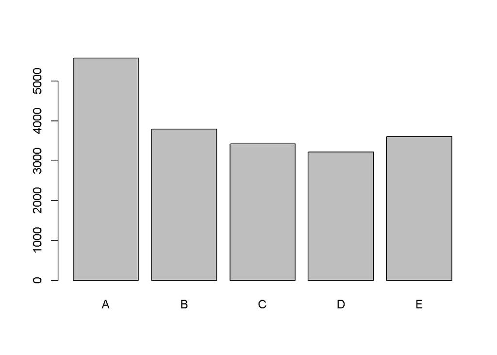

## Predictor Variable selection

```r
# Create a small sample of training data
pml_samp <- pml_train_data[createDataPartition(y=pml_train_data$classe,p=0.2,list=F),]

# Create Random Forest Model on dataset
rf_samp <- randomForest(classe ~., method="rf", data=pml_samp, importance=TRUE)
print (rf_samp)
```

```
##
## Call:
##  randomForest(formula = classe ~ ., data = pml_samp, method = "rf",      importance = TRUE)
##                Type of random forest: classification
##                      Number of trees: 500
## No. of variables tried at each split: 7
##
##         OOB estimate of  error rate: 3.64%
## Confusion matrix:
##     A   B   C   D   E class.error
## A 776   3   1   2   0 0.007672634
## B  18 498  16   0   0 0.063909774
## C   1  18 458   3   0 0.045833333
## D   2   1  22 423   3 0.062084257
## E   0   2   4   4 495 0.019801980
```

```r
# See how good the Model performs
res_samp <- predict(rf_samp,newdata=pml_train_data)
confusionMatrix(pml_train_data$classe, res_samp)
```

```
## Confusion Matrix and Statistics
##
##           Reference
## Prediction    A    B    C    D    E
##          A 3875   15   13    0    3
##          B   73 2517   58    8    2
##          C    3   65 2313   14    1
##          D    8    0  105 2135    4
##          E    0    7   13   13 2492
##
## Overall Statistics
##
##                Accuracy : 0.9705
##                  95% CI : (0.9676, 0.9733)
##     No Information Rate : 0.2882
##     P-Value [Acc > NIR] : < 2.2e-16
##
##                   Kappa : 0.9627
##  Mcnemar's Test P-Value : < 2.2e-16
##
## Statistics by Class:
##
##                      Class: A Class: B Class: C Class: D Class: E
## Sensitivity            0.9788   0.9666   0.9245   0.9839   0.9960
## Specificity            0.9968   0.9873   0.9926   0.9899   0.9971
## Pos Pred Value         0.9921   0.9470   0.9654   0.9480   0.9869
## Neg Pred Value         0.9915   0.9921   0.9833   0.9970   0.9991
## Prevalence             0.2882   0.1896   0.1821   0.1580   0.1821
## Detection Rate         0.2821   0.1832   0.1684   0.1554   0.1814
## Detection Prevalence   0.2843   0.1935   0.1744   0.1639   0.1838
## Balanced Accuracy      0.9878   0.9770   0.9585   0.9869   0.9965
```

```r
# Variable Importance to choose predictor variables for the final model
vrs <- varImp(rf_samp)

# Subset the data selecting the specific variable columns only
rws <- c(rownames(vrs)[1:18],"classe")
pml_train <- pml_train_data[,dput(rws)]
```

```
## c("roll_belt", "pitch_belt", "yaw_belt", "total_accel_belt",
## "gyros_belt_x", "gyros_belt_y", "gyros_belt_z", "accel_belt_x",
## "accel_belt_y", "accel_belt_z", "magnet_belt_x", "magnet_belt_y",
## "magnet_belt_z", "roll_arm", "pitch_arm", "yaw_arm", "total_accel_arm",
## "gyros_arm_x", "classe")
```

```r
pml_test <- pml_test_data[,dput(rws)]
```

```
## c("roll_belt", "pitch_belt", "yaw_belt", "total_accel_belt",
## "gyros_belt_x", "gyros_belt_y", "gyros_belt_z", "accel_belt_x",
## "accel_belt_y", "accel_belt_z", "magnet_belt_x", "magnet_belt_y",
## "magnet_belt_z", "roll_arm", "pitch_arm", "yaw_arm", "total_accel_arm",
## "gyros_arm_x", "classe")
```

Variable Importance Plot

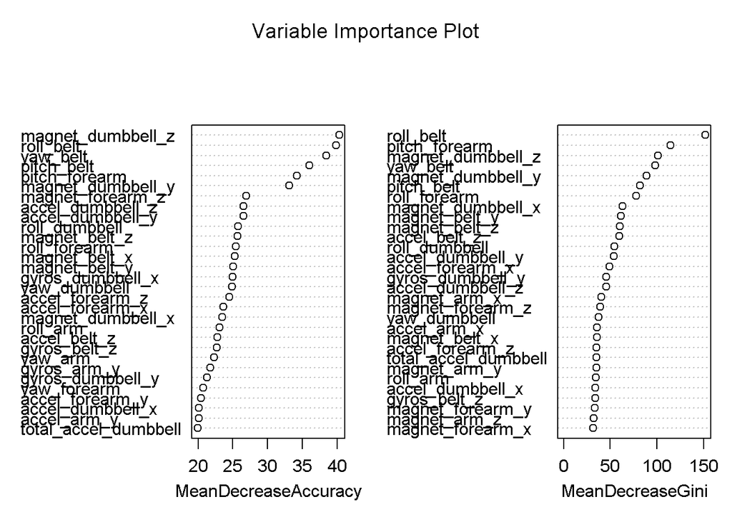

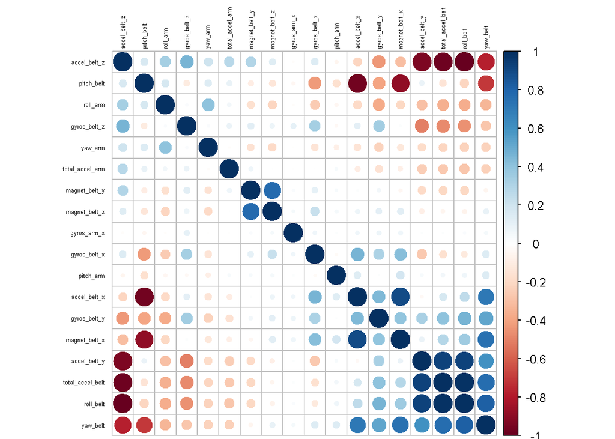

```r
# Find correlations between the chosen 18 predictor variables
corrs <- cor(pml_train[,-19])

# Plot the correlations
corrplot(corrs,order="FPC",method="circle",tl.cex=0.4,tl.col=rgb(0,0,0))
```

## Training the Final Model

As the Random Forest method by default uses oob(out-of-bag) cross-validation while training itself, thus we do not need to do extra cross-validation on the training set and can directly train the final model.

```r
# Train final Random Forest Model on entire dataset
rfModel <- train(classe ~.,method="rf",data=pml_train)
print (rfModel$finalModel)
```

```
##
## Call:
##  randomForest(x = x, y = y, mtry = param$mtry)
##                Type of random forest: classification
##                      Number of trees: 500
## No. of variables tried at each split: 2
##
##         OOB estimate of  error rate: 2.95%
## Confusion matrix:
##      A    B    C    D    E class.error
## A 3822   23   22   36    3  0.02150538
## B   40 2572   43    1    2  0.03235515
## C   21   79 2267   29    0  0.05383973
## D   17    3   44 2183    5  0.03063943
## E   11    9   13    4 2488  0.01465347
```

```r
# Test the In-Sample Error
in_samp <- predict(rfModel,newdata=pml_train)
confusionMatrix(pml_train$classe,in_samp)
```

```
## Confusion Matrix and Statistics
##
##           Reference
## Prediction    A    B    C    D    E
##          A 3906    0    0    0    0
##          B    0 2658    0    0    0
##          C    0    0 2396    0    0
##          D    0    0    0 2252    0
##          E    0    0    0    0 2525
##
## Overall Statistics
##
##                Accuracy : 1
##                  95% CI : (0.9997, 1)
##     No Information Rate : 0.2843
##     P-Value [Acc > NIR] : < 2.2e-16
##
##                   Kappa : 1
##  Mcnemar's Test P-Value : NA
##
## Statistics by Class:
##
##                      Class: A Class: B Class: C Class: D Class: E
## Sensitivity            1.0000   1.0000   1.0000   1.0000   1.0000
## Specificity            1.0000   1.0000   1.0000   1.0000   1.0000
## Pos Pred Value         1.0000   1.0000   1.0000   1.0000   1.0000
## Neg Pred Value         1.0000   1.0000   1.0000   1.0000   1.0000
## Prevalence             0.2843   0.1935   0.1744   0.1639   0.1838
## Detection Rate         0.2843   0.1935   0.1744   0.1639   0.1838
## Detection Prevalence   0.2843   0.1935   0.1744   0.1639   0.1838
## Balanced Accuracy      1.0000   1.0000   1.0000   1.0000   1.0000
```

### Expected Error on Cross-Validation

Cross-Validation with the hold out set created initially should give an error near the error rate for the training set. Greater variation may indicate that the model is overfitting the training data too much.

## Validation on Hold-out Set

Then the trained model was tested with the hold-out Validation data subset created earlier. This shows that a good accuracy, close to the expected value was achieved by the model.

```r
# Out of sample error on hold-out set (validation)
testResults <- predict(rfModel,newdata=pml_test)
confusionMatrix(pml_test$classe,testResults)
```

```
## Confusion Matrix and Statistics
##
##           Reference
## Prediction    A    B    C    D    E
##          A 1638   12   11   12    1
##          B   13 1106   16    2    2
##          C    5   29  972   20    0
##          D    7    2   13  940    2
##          E   13    3    9    0 1057
##
## Overall Statistics
##
##                Accuracy : 0.9708
##                  95% CI : (0.9661, 0.9749)
##     No Information Rate : 0.2848
##     P-Value [Acc > NIR] : < 2.2e-16
##
##                   Kappa : 0.963
##  Mcnemar's Test P-Value : 0.0007558
##
## Statistics by Class:
##
##                      Class: A Class: B Class: C Class: D Class: E
## Sensitivity            0.9773   0.9601   0.9520   0.9651   0.9953
## Specificity            0.9914   0.9930   0.9889   0.9951   0.9948
## Pos Pred Value         0.9785   0.9710   0.9474   0.9751   0.9769
## Neg Pred Value         0.9910   0.9903   0.9899   0.9931   0.9990
## Prevalence             0.2848   0.1958   0.1735   0.1655   0.1805
## Detection Rate         0.2783   0.1879   0.1652   0.1597   0.1796
## Detection Prevalence   0.2845   0.1935   0.1743   0.1638   0.1839
## Balanced Accuracy      0.9844   0.9765   0.9705   0.9801   0.9951
```

## Generating Files for Assignment Submission

```r
# Function to write to text files
pml_write_files = function(x){
  n = length(x)
  for(i in 1:n){
    filename = paste0("problem_id_",i,".txt")
    write.table(x[i],file=filename,quote=FALSE,row.names=FALSE,col.names=FALSE)
  }
}

# Load, clean Testing data, predict & write results to text files
test2 <- read.csv("pml-testing.csv", header=T, na.strings=c("NA",""," "))
test2 <- test2[,!sapply(test2,function(x) any(is.na(x)))]
test2 <- test2[,8:length(test2)]
assgn_preds <- predict(rfModel,newdata=test2)
pml_write_files(assgn_preds)
```

### Conclusion

Thus, very good accuracy was achieved using these techniques. However, a real-world scenario may require more optimised or regularized model.